# R - Week 2, workshop 3

Control flow, functions, loops, and scripting

Dr Hannah Jackson

## Learning outcomes

By the end of the session, you should be able to:

- Understand the idea of control flow in R
  - `for`
  - `if`
  - `else`
- Construct your own functions
- Understand lists
- Use the `apply()` family of functions
  - `apply()`
  - `lapply()`
  - `sapply()`
- Describe and implement scripting best practice

## What is the point of today?

- Previous sessions gave a basic grounding in how to use R
- Most users can get along fine with that level of knowledge
- More advanced techniques allow you to program more efficiently in R
- Allows greater flexibility and versitility - make R work for you
- Helps deepen your understanding of the fundementals

## How do I become an advanced R user?

- Requires more than just these sessions
- Practical, hands on experience
- Learn by doing, but also recognise when you need help
- Google, stackoverflow, me
- Write code that works, but be open to new techniques
- Find a way to focus that works for you
- Take a break and get away from it!

## Control flow

- A way of controlling the order that statements in a programming language are carried out
- `for`, `if`, `else` are all examples
- A bit more obvious with `if` and `else`?

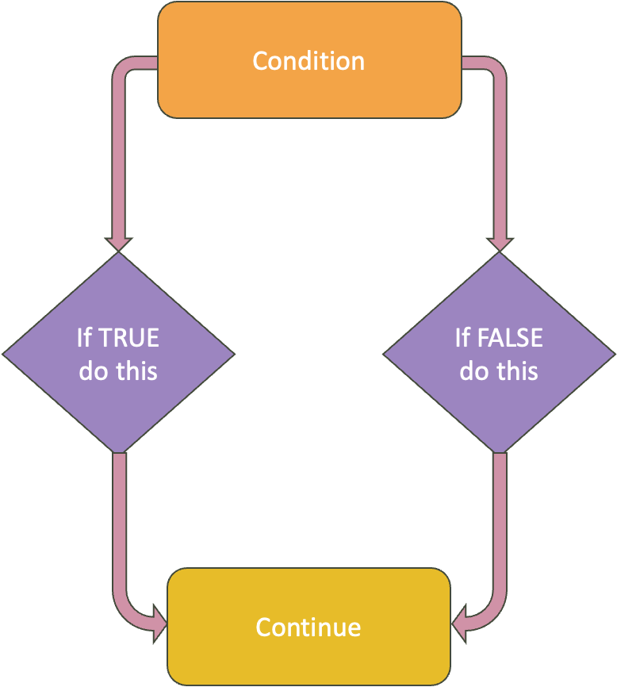

## A real world example

A real world example:

- Eating chocolate
- Outcome depends on whether conditional is `TRUE` or `FALSE`
- Obviously flawed (first answer is literally always true), but demonstrates principle

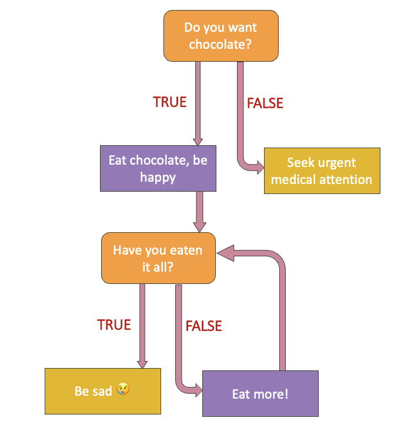

## A quick note on brackets

So far, we have seen different uses for brackets in R:

- Standard parentheses `()` for functions
- Square brackets `[]` for indexing/subsetting

…let’s make this even more complicated and add a third type!

- Curly brackets `{}` for defining blocks of code in functions or statements

[figure not shown]

# for loops 🥳

## `for` loops

- Incredibly useful if we want to perform the same operation on multiple things
- Structure in R is simple (but different syntax to Unix and Python, sorry)
- Use curly brackets to encompass code block `{}`
- Contstructed with:
  - A `for` statement
  - A data definition (i.e. what data do you want the loop to work on)
  - A function (i.e. the thing you want to be done to the data)

## Printing the numbers from 1 - 10

- we could do this without a loop:

```r
x <- 1
print(x)
```

```
[1] 1
```

```r
x <- 2
print(x)
```

```
[1] 2
```

- Much quicker with a loop! (too basic to be useful, but demonstrates a point)

```r
for (i in 1:10){
  print(i)
}
```

```
[1] 1
[1] 2
[1] 3
[1] 4
[1] 5
[1] 6
[1] 7
[1] 8
[1] 9
[1] 10
```

## Some basic loops:

- We can do loads of other stuff with loops
- To add 10 to each of the numbers, and print them…
- The loop assigns `i` the value of 1:10, adds 10 to it, and prints:

```r
for(i in 1:10){
  print(i+10)
}
```

```
[1] 11
[1] 12
[1] 13
[1] 14
[1] 15
[1] 16
[1] 17
[1] 18
[1] 19
[1] 20
```

## Some basic loops:

```r
for(potatoes in 1:5){
  print(potatoes)
}
```

```
[1] 1
[1] 2
[1] 3
[1] 4
[1] 5
```

## We can do this with character vectors:

- We can either pre-define our vector…

```r
animals <- c("dog", "hippo", "kangaroo")

for (animal in animals){
  y <- paste("I want a pet", animal)
  print(y)
}
```

```
[1] "I want a pet dog"
[1] "I want a pet hippo"
[1] "I want a pet kangaroo"
```

Notice what happens when we assign y - look in your environment

## We can do this with character vectors:

- Or, we can assign the values in the loop itself

```r
for (animal in c("dog", "hippo", "kangaroo")){
  y <- paste("I want a pet", animal)
  print(y)
}
```

```
[1] "I want a pet dog"
[1] "I want a pet hippo"
[1] "I want a pet kangaroo"
```

## If we don’t assign

- `paste()` doesn’t automatically print the output, we have to use `print()`
- We end up with a horrible nested function

```r
for (animal in c("dog", "hippo", "kangaroo")){
  print(paste("I want a pet", animal))
}
```

```
[1] "I want a pet dog"
[1] "I want a pet hippo"
[1] "I want a pet kangaroo"
```

- If we don’t use paste, we get separate strings

```r
for (animal in c("dog", "hippo", "kangaroo")){
  print(c("I want a pet", animal))
}
```

```
[1] "I want a pet" "dog"
[1] "I want a pet" "hippo"
[1] "I want a pet" "kangaroo"
```

## More for loops!

- we can assign the output of our loop to a new object:

```r
new_vector <- NA #create an empty vector to fill

#then add to it with a loop
for (x in 1:10){
  new_vector[x] <- x + 10
}

new_vector
```

```
 [1] 11 12 13 14 15 16 17 18 19 20
```

## More for loops!

- we can add a new column to an existing dataset

```r
library(tidyverse)
data(starwars) #load some data

starwars$size <- NA #create a new column

#add to it
for (i in 1:nrow(starwars)){
  starwars$size[i] <- starwars$height[i] * starwars$mass[i]
}

head(starwars)
```

```
# A tibble: 6 × 15
  name      height  mass hair_color skin_color eye_color birth_year sex   gender
  <chr>      <int> <dbl> <chr>      <chr>      <chr>          <dbl> <chr> <chr>
1 Luke Sky…    172    77 blond      fair       blue            19   male  mascu…
2 C-3PO        167    75 <NA>       gold       yellow         112   none  mascu…
3 R2-D2         96    32 <NA>       white, bl… red             33   none  mascu…
4 Darth Va…    202   136 none       white      yellow          41.9 male  mascu…
5 Leia Org…    150    49 brown      light      brown           19   fema… femin…
6 Owen Lars    178   120 brown, gr… light      blue            52   male  mascu…
# ℹ 6 more variables: homeworld <chr>, species <chr>, films <list>,
#   vehicles <list>, starships <list>, size <dbl>
```

# …but wait!

[figure not shown]

## Vectorisation - a better way?!

- Part of the joy of R is that we can acheive almost everything we’ve just tried with vectorisation
- This makes for more readable, faster, more efficient code
- `for` loops are not always unavoidable, so learn how they work!

```r
x <- 1:10
x
```

```
 [1]  1  2  3  4  5  6  7  8  9 10
```

```r
x <- 1:10
x + 10
```

```
 [1] 11 12 13 14 15 16 17 18 19 20
```

```r
animals <- c("dog", "hippo", "kangaroo")
paste("I want a pet", animals)
```

```
[1] "I want a pet dog"      "I want a pet hippo"    "I want a pet kangaroo"
```

## Summary:

`for` loops automate repetitive tasks, and do many iterations of the same thing.

`for (variable in sequence){`

`do some stuff`

`}`

# Conditionals

## If statements

- Another e.g. of control flow
- allows you to perform an action `if` a condition is met
- Here, nothing will be printed if the condition is not met:

```r
z <- 1

if(z < 10){
  print("z is less than 10")
}
```

```
[1] "z is less than 10"
```

```r
z <- 35

if(z < 10){
  print("z is less than 10")
}
```

## `else` statements

- can be combined with `if` to provide an alternative when a condition is **not** met

```r
z <- 1

if(z < 10){
  print("z is less than 10")
} else {
  print("z is more than 10")
}
```

```
[1] "z is less than 10"
```

```r
z <- 35

if(z < 10){
  print("z is less than 10")
} else {
  print("z is more than 10")
}
```

```
[1] "z is more than 10"
```

## `ifelse` - an easier way?

- the `ifelse()` function provides an alternative way to use if/else control flow
- a little simpler and more versatile - can easily be applied to vectors:
- syntax: `ifelse(condition, if true, if false)`

```r
z <- 1
ifelse(z < 10, "less than 10", "more than 10")
```

```
[1] "less than 10"
```

```r
z <- 36
ifelse(z < 10, "less than 10", "more than 10")
```

```
[1] "more than 10"
```

- also works with character strings

```r
food <- c("apple", "chocolate", "potato")

ifelse(food == "chocolate", "delicious", "rubbish")
```

```
[1] "rubbish"   "delicious" "rubbish"
```

## When is it useful?

- creating new variables dependent on the values of other columns
- let’s go back to the starwars universe…
- we want all of the ewoks…

```r
starwars$ewok <- ifelse(starwars$species == "Ewok", "ewok", "not an ewok")
starwars %>%
  select(name, species, ewok) %>%
  print(n = 30)
```

```
# A tibble: 87 × 3
   name                  species        ewok
   <chr>                 <chr>          <chr>
 1 Luke Skywalker        Human          not an ewok
 2 C-3PO                 Droid          not an ewok
 3 R2-D2                 Droid          not an ewok
 4 Darth Vader           Human          not an ewok
 5 Leia Organa           Human          not an ewok
 6 Owen Lars             Human          not an ewok
 7 Beru Whitesun Lars    Human          not an ewok
 8 R5-D4                 Droid          not an ewok
 9 Biggs Darklighter     Human          not an ewok
10 Obi-Wan Kenobi        Human          not an ewok
11 Anakin Skywalker      Human          not an ewok
12 Wilhuff Tarkin        Human          not an ewok
```

[output cut: 19 more lines]

## More than 1 condition

- what if I want all the furry species?

```r
starwars$furry <- ifelse((starwars$species == "Ewok" | starwars$species == "Wookiee"),
                          "furry",
                          "not furry")
starwars %>%
  select(name, species, ewok, furry) %>%
  print(n = 30)
```

```
# A tibble: 87 × 4
   name                  species        ewok        furry
   <chr>                 <chr>          <chr>       <chr>
 1 Luke Skywalker        Human          not an ewok not furry
 2 C-3PO                 Droid          not an ewok not furry
 3 R2-D2                 Droid          not an ewok not furry
 4 Darth Vader           Human          not an ewok not furry
 5 Leia Organa           Human          not an ewok not furry
 6 Owen Lars             Human          not an ewok not furry
 7 Beru Whitesun Lars    Human          not an ewok not furry
 8 R5-D4                 Droid          not an ewok not furry
 9 Biggs Darklighter     Human          not an ewok not furry
10 Obi-Wan Kenobi        Human          not an ewok not furry
11 Anakin Skywalker      Human          not an ewok not furry
12 Wilhuff Tarkin        Human          not an ewok not furry
```

[output cut: 19 more lines]

# Building your own functions

[figure not shown]

## Writing a function…

- Often, you will need to write your own functions in R
- Keeps code simple and readable
- Reduces duplication (and painful hours of copy & pasting & tweaking code…)
- Very simple!

[figure not shown]

## The anatomy of a function

```r
add_ten <- function(x){
  y <- x + 10
  return(y)
}
```

- `function(x)` - declares the function and the arguments it requires
- `{}` defines a block of code
- `y <- x + 10` - this bit is fairly obvious, add 10 to x
- note here that `y` is only defined *within* the function - it will not appear in your global environment!
- `return()` tells R what output to send from the function at the end. Without it, R won’t always give us an output.

```r
add_ten(1)
```

```
[1] 11
```

Vector input:

```r
add_ten(1:10)
```

```
 [1] 11 12 13 14 15 16 17 18 19 20
```

## Functions with multiple arguments

- functions can take more than one argument
- let’s write one that will multiply two numbers…
- we can also provide *default* arguments

```r
multiply <- function(x, y){
  z <- x * y
  return(z)
  }

multiply(2, 4)
```

```
[1] 8
```

with a default…

```r
multiply <- function(x, y = 10){
  z <- x * y
  return(z)
  }

multiply(2)
```

```
[1] 20
```

## We can override defaults

```r
multiply <- function(x, y = 10){
  z <- x * y
  return(z)
  }

multiply(2, 5)
```

```
[1] 10
```

[figure not shown]

## Combining functions with conditionals

- often functions will need conditional control flow statements
- here we have a function that evaluates whether a number is greater than or less than 10:

```r
eval10 <- function(x){
  y <- ifelse(x < 10,
              "less than 10",
              "greater than 10")
  return(y)
}

eval10(1)
```

```
[1] "less than 10"
```

```r
eval10(463)
```

```
[1] "greater than 10"
```

## There is always more than one way!!

- we could achieve exactly the same thing with `if` and `else`

```r
eval10 <- function(x){
  y <- if(x < 10){
    print("less than 10")
  } else {
    print("greater than 10")
  }
}

eval10(1)
```

```
[1] "less than 10"
```

```r
eval10(463)
```

```
[1] "greater than 10"
```

- note that we don’t need `return(y)` here because `print()` does the job for us

## Have a go:

1. Write a for loop to iterate over the numbers 1 to 100, multiply each one by 5, and print the output
2. Write an if statement to multiply a number by 10, **but** only if it is under 100
3. Write an `ifelse()` statement to out “x is big” if x is greater than or equal to 20, and “x is small” if x is less than 20
4. Write a function to divide one input by another, and return an output
5. Modify that function to have a defualt value for one input
6. Write a function to add 50 to an input, **but** only if that input is less than 50
7. **brucey bonus:** use nested `ifelse()` statements to add a new factor variable to the airquality dataset, which has a value of “early” if the day is 10 or under, “middle” if the day is 11-12, and “late” if the day is 21 or greater (this one is tricky!)

# Lists

## Lists: what are they?

- Think of a list as a special type of vector, that can contain different objects **of a different length**.
- i.e. a list could contain a vector of length 4, but also a matrix with a length of 10.
- More complex than other data types
- Can include all of the other data structures, including lists themselves
- Very powerful in some cases
- Helpful for storing multiple dataframes, tibbles, vectors (for e.g. the outputs of complex functions)
- Useful in combination with `apply()` family of functions

## Let’s make one…

First, we make 3 vectors of different lengths

```r
names <- c("Hannah", "Laura", "Matt")
numbers <- 1:100
logic <- c(TRUE, FALSE, TRUE, FALSE)
```

…then we stick ’em together using the `list()` function

```r
my_list <- list(names, numbers, logic)
my_list
```

```
[[1]]
[1] "Hannah" "Laura"  "Matt"

[[2]]
  [1]   1   2   3   4   5   6   7   8   9  10  11  12  13  14  15  16  17  18
 [19]  19  20  21  22  23  24  25  26  27  28  29  30  31  32  33  34  35  36
 [37]  37  38  39  40  41  42  43  44  45  46  47  48  49  50  51  52  53  54
 [55]  55  56  57  58  59  60  61  62  63  64  65  66  67  68  69  70  71  72
 [73]  73  74  75  76  77  78  79  80  81  82  83  84  85  86  87  88  89  90
 [91]  91  92  93  94  95  96  97  98  99 100

[[3]]
[1]  TRUE FALSE  TRUE FALSE
```

## How lists work

- we can use `[]`, but with a difference
- let’s try to access the first element in our list

```r
my_list[1]
```

```
[[1]]
[1] "Hannah" "Laura"  "Matt"
```

- now, we’ll check the class:

```r
class(my_list[1])
```

```
[1] "list"
```

…it’s still a list?!

## How lists work

- we can access the underlying vectors with double square brackets `[[]]`

```r
my_list[[1]]
```

```
[1] "Hannah" "Laura"  "Matt"
```

```r
class(my_list[[1]])
```

```
[1] "character"
```

- Be aware that there is only a single dimension we can access with `[[]]` - the list item index. `[[1,2]]` will not work!

## Lists and colons

- The colon `:` works differently inside of a list (sorry)

```r
my_list[1:2]
```

```
[[1]]
[1] "Hannah" "Laura"  "Matt"

[[2]]
  [1]   1   2   3   4   5   6   7   8   9  10  11  12  13  14  15  16  17  18
 [19]  19  20  21  22  23  24  25  26  27  28  29  30  31  32  33  34  35  36
 [37]  37  38  39  40  41  42  43  44  45  46  47  48  49  50  51  52  53  54
 [55]  55  56  57  58  59  60  61  62  63  64  65  66  67  68  69  70  71  72
 [73]  73  74  75  76  77  78  79  80  81  82  83  84  85  86  87  88  89  90
 [91]  91  92  93  94  95  96  97  98  99 100
```

As we might expect, gives the first and second elements of the list (as lists)

```r
my_list[[1:2]]
```

```
[1] "Laura"
```

Gives the second element of the first vector in the list?!

## Accessing elements within a list

- The most common way of accessing elements in a list is combining the single and double brackets

```r
my_list[[1]][2]
```

```
[1] "Laura"
```

```r
my_list[[1]][1:2]
```

```
[1] "Hannah" "Laura"
```

## Named lists

- we can use element names to access things in lists, but **only** if we pre-defined those names when creating the list

```r
my_list
```

```
[[1]]
[1] "Hannah" "Laura"  "Matt"

[[2]]
  [1]   1   2   3   4   5   6   7   8   9  10  11  12  13  14  15  16  17  18
 [19]  19  20  21  22  23  24  25  26  27  28  29  30  31  32  33  34  35  36
 [37]  37  38  39  40  41  42  43  44  45  46  47  48  49  50  51  52  53  54
 [55]  55  56  57  58  59  60  61  62  63  64  65  66  67  68  69  70  71  72
 [73]  73  74  75  76  77  78  79  80  81  82  83  84  85  86  87  88  89  90
 [91]  91  92  93  94  95  96  97  98  99 100

[[3]]
[1]  TRUE FALSE  TRUE FALSE
```

## Named lists

```r
my_list <- list(names = names, numbers = numbers, logic = logic)
my_list
```

```
$names
[1] "Hannah" "Laura"  "Matt"

$numbers
  [1]   1   2   3   4   5   6   7   8   9  10  11  12  13  14  15  16  17  18
 [19]  19  20  21  22  23  24  25  26  27  28  29  30  31  32  33  34  35  36
 [37]  37  38  39  40  41  42  43  44  45  46  47  48  49  50  51  52  53  54
 [55]  55  56  57  58  59  60  61  62  63  64  65  66  67  68  69  70  71  72
 [73]  73  74  75  76  77  78  79  80  81  82  83  84  85  86  87  88  89  90
 [91]  91  92  93  94  95  96  97  98  99 100

$logic
[1]  TRUE FALSE  TRUE FALSE
```

we’ve replaced [[1]] with names, etc.

## Named lists

- now we can access the elements like this:

```r
my_list$names
```

```
[1] "Hannah" "Laura"  "Matt"
```

```r
my_list[["logic"]][2]
```

```
[1] FALSE
```

[figure not shown]

# the `apply()` family

[figure not shown]

## `apply()` functions

- apply functions are an alternative to for loops that allow you to apply a function to a data structure
- essentially designed to avoid loops, and usually (but not always) much faster
- quite complex, and not well explained
- Takes time to get used to, but worth it!

## `apply()` functions

- today, we’ll look at 3 core functions
  - `apply()`: wotks on matricies or dataframes
  - `lapply()`: works with lists, and outputs lists
  - `sapply()`: similar to lapply, but simplifies output
- other functions are available, but understanding these is a first step

## `apply()`

- simple structure: `apply(data, row_or_column, function_name)`
- in `row_or_column`, 1 means row, 2 means column
- highly flexible, can use any function (inc. user defined ones)
- let’s have a go with the `airquality` dataset

```r
data(airquality)
```

- we want to find the means of all of the columns…

## There are lots of ways that we can do this…

```r
mean(airquality[,1], na.rm = TRUE)
```

```
[1] 42.12931
```

```r
mean(airquality[,2], na.rm = TRUE)
```

```
[1] 185.9315
```

…etc

…or we could use a for loop

```r
for(col in 1:ncol(airquality)){
  print(mean(airquality[,col], na.rm = T))
}
```

```
[1] 42.12931
[1] 185.9315
[1] 9.957516
[1] 77.88235
[1] 6.993464
[1] 15.80392
```

## OR, we could use `apply()`!

```r
apply(airquality, 2, mean)
```

```
    Ozone   Solar.R      Wind      Temp     Month       Day
       NA        NA  9.957516 77.882353  6.993464 15.803922
```

- we can pass additional arguments at the end of apply

```r
apply(airquality, 2, mean, na.rm = T)
```

```
     Ozone    Solar.R       Wind       Temp      Month        Day
 42.129310 185.931507   9.957516  77.882353   6.993464  15.803922
```

- In this case, there is a baseR function that would do this for us, `colMeans`

```r
colMeans(airquality, na.rm = T)
```

```
     Ozone    Solar.R       Wind       Temp      Month        Day
 42.129310 185.931507   9.957516  77.882353   6.993464  15.803922
```

- There is always more than 1 way to solve a problem!

## Going further with `apply()`

- we can write our own functions and use them with `apply()`

A function to square a series of values:

```r
square <- function(x){
  y <- x^2
  return(y)
  }
```

```r
square(10)
```

```
[1] 100
```

with apply:

```r
apply(airquality, 2, square)
```

```
       Ozone Solar.R   Wind Temp Month Day
  [1,]  1681   36100  54.76 4489    25   1
  [2,]  1296   13924  64.00 5184    25   4
  [3,]   144   22201 158.76 5476    25   9
  [4,]   324   97969 132.25 3844    25  16
  [5,]    NA      NA 204.49 3136    25  25
  [6,]   784      NA 222.01 4356    25  36
  [7,]   529   89401  73.96 4225    25  49
  [8,]   361    9801 190.44 3481    25  64
  [9,]    64     361 404.01 3721    25  81
 [10,]    NA   37636  73.96 4761    25 100
 [11,]    49      NA  47.61 5476    25 121
 [12,]   256   65536  94.09 4761    25 144
 [13,]   121   84100  84.64 4356    25 169
 [14,]   196   75076 118.81 4624    25 196
```

[output cut: 139 more lines]

## Every entry in the dataset is squared!

…of course, we could just do

```r
airquality^2
```

```
    Ozone Solar.R   Wind Temp Month Day
1    1681   36100  54.76 4489    25   1
2    1296   13924  64.00 5184    25   4
3     144   22201 158.76 5476    25   9
4     324   97969 132.25 3844    25  16
5      NA      NA 204.49 3136    25  25
6     784      NA 222.01 4356    25  36
7     529   89401  73.96 4225    25  49
8     361    9801 190.44 3481    25  64
9      64     361 404.01 3721    25  81
10     NA   37636  73.96 4761    25 100
11     49      NA  47.61 5476    25 121
12    256   65536  94.09 4761    25 144
13    121   84100  84.64 4356    25 169
14    196   75076 118.81 4624    25 196
```

[output cut: 139 more lines]

- always look for the path of least resistance

## Anonymous functions with `apply()`

- You can define a custom function within the body of apply, rather than defining separately first
- This is called an anonymous function
- The code nests like brackets in a mathematical function
- Let’s try with our `square` function

```r
apply(airquality, 2, function(x){
  x^2
})
```

```
       Ozone Solar.R   Wind Temp Month Day
  [1,]  1681   36100  54.76 4489    25   1
  [2,]  1296   13924  64.00 5184    25   4
  [3,]   144   22201 158.76 5476    25   9
  [4,]   324   97969 132.25 3844    25  16
  [5,]    NA      NA 204.49 3136    25  25
  [6,]   784      NA 222.01 4356    25  36
  [7,]   529   89401  73.96 4225    25  49
  [8,]   361    9801 190.44 3481    25  64
  [9,]    64     361 404.01 3721    25  81
 [10,]    NA   37636  73.96 4761    25 100
 [11,]    49      NA  47.61 5476    25 121
 [12,]   256   65536  94.09 4761    25 144
 [13,]   121   84100  84.64 4356    25 169
 [14,]   196   75076 118.81 4624    25 196
```

[output cut: 139 more lines]

## We can try with a more complicated function

- lets count the number of NAs in each column

```r
apply(airquality, 2, function(x){
  is.na(x)
})
```

```
       Ozone Solar.R  Wind  Temp Month   Day
  [1,] FALSE   FALSE FALSE FALSE FALSE FALSE
  [2,] FALSE   FALSE FALSE FALSE FALSE FALSE
  [3,] FALSE   FALSE FALSE FALSE FALSE FALSE
  [4,] FALSE   FALSE FALSE FALSE FALSE FALSE
  [5,]  TRUE    TRUE FALSE FALSE FALSE FALSE
  [6,] FALSE    TRUE FALSE FALSE FALSE FALSE
  [7,] FALSE   FALSE FALSE FALSE FALSE FALSE
  [8,] FALSE   FALSE FALSE FALSE FALSE FALSE
  [9,] FALSE   FALSE FALSE FALSE FALSE FALSE
 [10,]  TRUE   FALSE FALSE FALSE FALSE FALSE
 [11,] FALSE    TRUE FALSE FALSE FALSE FALSE
 [12,] FALSE   FALSE FALSE FALSE FALSE FALSE
 [13,] FALSE   FALSE FALSE FALSE FALSE FALSE
 [14,] FALSE   FALSE FALSE FALSE FALSE FALSE
```

[output cut: 139 more lines]

## We can try with a more complicated function

- now we have an output of logical values, we can sum the `TRUE` instances

```r
apply(airquality, 2, function(x){
  sum(is.na(x))
})
```

```
  Ozone Solar.R    Wind    Temp   Month     Day
     37       7       0       0       0       0
```

- we get an output by column, which is useful!

## `lapply()`

- `lapply()` is essentially `apply()`, but for lists
- It works in the same way, but you can either feed it a dataframe, or a list
- Let’s have a look at our list

```r
my_list
```

```
$names
[1] "Hannah" "Laura"  "Matt"

$numbers
  [1]   1   2   3   4   5   6   7   8   9  10  11  12  13  14  15  16  17  18
 [19]  19  20  21  22  23  24  25  26  27  28  29  30  31  32  33  34  35  36
 [37]  37  38  39  40  41  42  43  44  45  46  47  48  49  50  51  52  53  54
 [55]  55  56  57  58  59  60  61  62  63  64  65  66  67  68  69  70  71  72
 [73]  73  74  75  76  77  78  79  80  81  82  83  84  85  86  87  88  89  90
 [91]  91  92  93  94  95  96  97  98  99 100

$logic
[1]  TRUE FALSE  TRUE FALSE
```

## `lapply()`

- We can start by applying the `length` function to each element
- We don’t have to provide a dimension, because lists only have 1 (the number of elements)

```r
lapply(my_list, length)
```

```
$names
[1] 3

$numbers
[1] 100

$logic
[1] 4
```

## Giving `lapply()` a dataframe

- If we give a dataframe in the data argument of `lapply()`, it will coerce it into a list before it does anything with it
- What does the `airquality` dataset look like as a list?

```r
as.list(airquality)
```

```
$Ozone
  [1]  41  36  12  18  NA  28  23  19   8  NA   7  16  11  14  18  14  34   6
 [19]  30  11   1  11   4  32  NA  NA  NA  23  45 115  37  NA  NA  NA  NA  NA
 [37]  NA  29  NA  71  39  NA  NA  23  NA  NA  21  37  20  12  13  NA  NA  NA
 [55]  NA  NA  NA  NA  NA  NA  NA 135  49  32  NA  64  40  77  97  97  85  NA
 [73]  10  27  NA   7  48  35  61  79  63  16  NA  NA  80 108  20  52  82  50
 [91]  64  59  39   9  16  78  35  66 122  89 110  NA  NA  44  28  65  NA  22
[109]  59  23  31  44  21   9  NA  45 168  73  NA  76 118  84  85  96  78  73
[127]  91  47  32  20  23  21  24  44  21  28   9  13  46  18  13  24  16  13
[145]  23  36   7  14  30  NA  14  18  20

$Solar.R
  [1] 190 118 149 313  NA  NA 299  99  19 194  NA 256 290 274  65 334 307  78
 [19] 322  44   8 320  25  92  66 266  NA  13 252 223 279 286 287 242 186 220
 [37] 264 127 273 291 323 259 250 148 332 322 191 284  37 120 137 150  59  91
```

[output cut: 44 more lines]

## Giving `lapply()` a dataframe

- Let’s try using `lapply()` to work out the mean of the dataset

```r
lapply(airquality, mean)
```

```
$Ozone
[1] NA

$Solar.R
[1] NA

$Wind
[1] 9.957516

$Temp
[1] 77.88235

$Month
[1] 6.993464

$Day
[1] 15.80392
```

- Note that the output of `lapply()` is a list

## Giving `lapply()` a dataframe

- As with `apply()`, we can pass additional arguments:

```r
lapply(airquality, mean, na.rm = T)
```

```
$Ozone
[1] 42.12931

$Solar.R
[1] 185.9315

$Wind
[1] 9.957516

$Temp
[1] 77.88235

$Month
[1] 6.993464

$Day
[1] 15.80392
```

```r
lapply(airquality, mean, na.rm = T) %>%
  class()
```

```
[1] "list"
```

## `sapply()`: simplify apply

- Works in an almost identical way to `lapply()`, but with the option to simplify the output from a list to a vector
- Arguably the most versatile of the apply family, as it takes any input, and you can control the output type
- Let’s try again with the airquality data means

```r
sapply(airquality, mean, na.rm = T)
```

```
     Ozone    Solar.R       Wind       Temp      Month        Day
 42.129310 185.931507   9.957516  77.882353   6.993464  15.803922
```

- The default behaviour for `sapply()` is to simplify, but we can override this

```r
sapply(airquality, mean, na.rm = T, simplify = F)
```

```
$Ozone
[1] 42.12931

$Solar.R
[1] 185.9315

$Wind
[1] 9.957516

$Temp
[1] 77.88235

$Month
[1] 6.993464

$Day
[1] 15.80392
```

## `sapply()`: simplify apply

- We can also give `sapply()` lists, and control whether the output is simplified or not:

```r
sapply(my_list, length)
```

```
  names numbers   logic
      3     100       4
```

```r
sapply(my_list, length, simplify = F)
```

```
$names
[1] 3

$numbers
[1] 100

$logic
[1] 4
```

## `sapply()` with anonymous functions

- Let’s have a go, how might we use `sapply()` to take the square root of each number in a vector from 1:10?
- `sapply`
- `1:10` as input data
- `function(x){...}` as function
- `sqrt(x)` inside the body of the anonymous function

```r
sapply(1:10, function(x){
  sqrt(x)
})
```

```
 [1] 1.000000 1.414214 1.732051 2.000000 2.236068 2.449490 2.645751 2.828427
 [9] 3.000000 3.162278
```

```r
sapply(1:10, function(x){
  sqrt(x)
}, simplify = F)
```

```
[[1]]
[1] 1

[[2]]
[1] 1.414214

[[3]]
[1] 1.732051

[[4]]
[1] 2

[[5]]
[1] 2.236068

[[6]]
[1] 2.44949

[[7]]
[1] 2.645751

[[8]]
[1] 2.828427

[[9]]
[1] 3

[[10]]
[1] 3.162278
```

## To do that with a for loop would be complicated:

```r
for (i in 1:10) { # define the vector
  if (i == 1) sqrt_list <- list() # create a new list on the first instance
  sqrt_list[[i]] <- sqrt(i) # add a new element to the list, and pop the sqrt in
}
sqrt_list
```

```
[[1]]
[1] 1

[[2]]
[1] 1.414214

[[3]]
[1] 1.732051

[[4]]
[1] 2

[[5]]
[1] 2.236068

[[6]]
[1] 2.44949

[[7]]
[1] 2.645751

[[8]]
[1] 2.828427

[[9]]
[1] 3

[[10]]
[1] 3.162278
```

## …but

```r
as.list(sqrt(1:10))
```

```
[[1]]
[1] 1

[[2]]
[1] 1.414214

[[3]]
[1] 1.732051

[[4]]
[1] 2

[[5]]
[1] 2.236068

[[6]]
[1] 2.44949

[[7]]
[1] 2.645751

[[8]]
[1] 2.828427

[[9]]
[1] 3

[[10]]
[1] 3.162278
```

## `sapply()` with characters

- What if we want to create a series of 24 new column names, one for each chromosome in the genome for e.g.?

```r
sapply(1:24, function(x){
  paste("chr", x, sep = "_")
})
```

```
 [1] "chr_1"  "chr_2"  "chr_3"  "chr_4"  "chr_5"  "chr_6"  "chr_7"  "chr_8"
 [9] "chr_9"  "chr_10" "chr_11" "chr_12" "chr_13" "chr_14" "chr_15" "chr_16"
[17] "chr_17" "chr_18" "chr_19" "chr_20" "chr_21" "chr_22" "chr_23" "chr_24"
```

- …but again:

```r
paste("chr", 1:24, sep = "_")
```

```
 [1] "chr_1"  "chr_2"  "chr_3"  "chr_4"  "chr_5"  "chr_6"  "chr_7"  "chr_8"
 [9] "chr_9"  "chr_10" "chr_11" "chr_12" "chr_13" "chr_14" "chr_15" "chr_16"
[17] "chr_17" "chr_18" "chr_19" "chr_20" "chr_21" "chr_22" "chr_23" "chr_24"
```

## Top tip for being a great programmer: be lazy!

- Look for the easy way!!!

[figure not shown]

# Writing sensible R scripts:

- Somewhat different to other languages, not just simply a program you write and then run
- An annotated guide to your code - what you did and how you did it
- Making effort to put together a logical and well-designed script is useful for you and the people you share it with

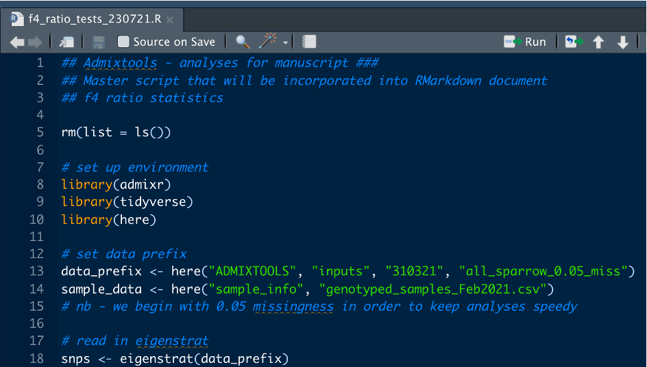

## R scripts: a guide

- Start off with an explanation of what the script is
- Date/author are a good idea
- There are more advanced templates, have a google but don’t worry too much

```r
# A script to analyse height
# and mass data
# Author: Hannah Jackson
# Date: 21st Oct, 2025
```

## R scripts: a guide

- Clear the environment
- `rm(list = ls())` will remove all objects from a library
- Controversial
- Advantages: clears environment and prevents conflicts
- Disadvantage: will also remove objects got anyone you shrae it with
- Comment it out?

```r
# A script to analyse height
# and mass data
# Author: Hannah Jackson
# Date: 21st Oct, 2025

# clear environ
rm(list = ls())
```

## R scripts: a guide

- Install (but comment out?) packages
- Load all the packages/data you need for the script

```r
# A script to analyse height
# and mass data
# Author: Hannah Jackson
# Date: 21st Oct, 2025

# clear environ
rm(list = ls())

# package management
#install.packages("tidyverse")
library(dplyr)
library(ggplot2)
```

## R scripts: a guide

- Declare all objects and paths you’ll need within the script
- Also declare a working directory if that’s how you prefer to manage R

```r
# A script to analyse height
# and mass data
# Author: Hannah Jackson
# Date: 21st Oct, 2025

# clear environ
rm(list = ls())

# package management
#install.packages("tidyverse")
library(dplyr)
library(ggplot2)

# declare objects and paths
data_path <- "./starwars_data.csv"
starwars <- read.csv(data_path)
```

## R scripts: a guide

- Annotate the working parts properly with comments

```r
# A script to analyse height
# and mass data
# Author: Hannah Jackson
# Date: 21st Oct, 2025

# clear environ
rm(list = ls())

# package management
#install.packages("tidyverse")
library(dplyr)
library(ggplot2)

# declare objects and paths
data_path <- "./starwars_data.csv"
starwars <- read.csv(data_path)

# count species
starwars %>%
  count(species)
```

## Other tips:

- Set R up so that it does NOT save your workspace every time you exit
- To do this: `RStudio > preferences > workspace`

[figure not shown]

## Have a go:

1. Create a new list, with 5 named elements. Make sure you include logical, chacater, two numeric elements, and at least one dataframe.
2. Using its number, access the second element in the list, and return it (as a list!)
3. Using its number, access the second element in the list, and return it as a vector or dataframe (whichever it would be outside of the context of the list)
4. Using its name, access the 5th element of the list
5. Using `apply()`, find the total sums of each column in the `airquality` dataset (note: you’ll need to reload the dataset to remove the column we added to it earlier)
6. Using `lapply()`, print the classes of the items in the list that you made in question 1.
7. **Brucey bonus:** Using `apply()`, paired with your own custom function, output the square root of the lengths of each item in the list you created in question 1

## Next time:

- Reading and manipulating VCF files in R
- Principal components analysis (PCA)
- Running R scripts from the terminal

[figure not shown]